# Deep C++(V17.02)

autor:ichiroprogrammer

# インデックス

SOLID  
単一責任の原則(SRP)  
オープン・クローズドの原則(OCP)  
リスコフの置換原則(LSP)  
インターフェース分離の原則(ISP)  
依存関係逆転の原則(DIP)  
まとめ

デザインパターン  
ガード節  
BitmaskType  
Pimpl  
Accessor  
Copy-And-Swap  
Immutable  
Clone(仮想コンストラクタ)  
NVI(non virtual interface)  
RAII(scoped guard)  
Future  
DI(dependency injection)  
Singleton  
State  
Null Object  
Templateメソッド  
Factory  
Named Constructor  
Proxy  
Strategy  
Visitor  
CRTP(curiously recurring template pattern)  
Observer  
MVC  
Cでのクラス表現

テンプレートメタプログラミング  
ログ取得ライブラリの開発  
Nstdライブラリの開発  
メタ関数のテクニック  
Nstdライブラリの開発2  
ログ取得ライブラリの開発2  
その他のテンプレートテクニック  
注意点まとめ

ダイナミックメモリアロケーション  
malloc/freeの問題点  
グローバルnew/deleteのオーバーロード  
クラスnew/deleteのオーバーロード  
STLコンテナのアロケーター

用語解説  
型とインスタンス  
オブジェクトと生成  
オブジェクトのコピー  
name lookupと名前空間  
expressionと値カテゴリ  
リファレンス  
エクセプション安全性の保証  
シンタックス、セマンティクス  
C++コンパイラ  
C++その他  
ソフトウェア一般  
非ソフトウェア用語

Sample Code  
C++

# SOLID

SOLIDとは、オブジェクト指向(OOD/OOP)プログラミングにおいて特に重要な下記の5つの原則である。

- 単一責任の原則(SRP)
- オープン・クローズドの原則(OCP)
- リスコフの置換原則(LSP)
- インターフェース分離の原則(ISP)
- 依存関係逆転の原則(DIP)

## 単一責任の原則(SRP)

単一責任の原則(SRP, Single Responsibility Principle)とは、

- 一つのクラスは、ただ一つの責任(機能)を持つようにしなければならない
- 一つのクラスは、ただ一つの理由で変更されるように作られなければならない

というクラスデザイン上の制約である。

下記クラスSentenceHolderNotSRPは、一見問題ないように見えるが、std::stringの保持と、 その出力という二つの責務を持つため、SRP違反である。

```cpp
    // @@@ example/solid/srp_ut.cpp 27

    class SentenceHolderNotSRP {
    public:
        SentenceHolderNotSRP()  = default;
        ~SentenceHolderNotSRP() = default;

        void Add(std::string const& sentence) { sentence_ += sentence; }

        std::string const& Get() const noexcept { return sentence_; }

        void Save(std::string const& file)
        {
            std::ofstream o{file};
            o << sentence_;
        }

        void Display() { std::cout << sentence_; }

    private:
        std::string sentence_{};
    };
```

実践的にはこの程度の単純なクラスでのSRP違反が問題になることは少ないが、 下記のコメントで示す通り、単体テストの実施が困難になる。

```cpp
    // @@@ example/solid/srp_ut.cpp 53

    auto not_srp = SentenceHolderNotSRP{};

    not_srp.Add("haha\n");
    not_srp.Add("hihi\n");
    not_srp.Add("huhu\n");

    // SRPに従っていないため、テストが面倒
    not_srp.Save(not_srp_text_);  // not_srp_text_への書き込み

    auto ifs       = std::ifstream{not_srp_text_};
    auto ifs_begin = std::istreambuf_iterator<char>{ifs};
    auto ifs_end   = std::istreambuf_iterator<char>{};
    auto act       = std::string{ifs_begin, ifs_end};  // not_srp_text_ファイルの読み出し

    ASSERT_EQ("haha\nhihi\nhuhu\n", act);

    // SRPに従っていないため、テストできない
    not_srp.Display();
```

クラスSentenceHolderNotSRPの二つの責務をクラスSentenceHolderSRPと、 Output()に分離したコード実装例を下記する。

```cpp
    // @@@ example/solid/srp_ut.cpp 75

    class SentenceHolderSRP {
    public:
        SentenceHolderSRP()  = default;
        ~SentenceHolderSRP() = default;

        void Add(std::string const& sentence) { sentence_ += sentence; }

        std::string const& Get() const noexcept { return sentence_; }

    private:
        std::string sentence_{};
    };

    // SRPに従うために、
    //    SentenceHolderNotSRP::Save(), SentenceHolderNotSRP::Display()
    // をクラスの外に出し、さらに仮引数に出力先(std::ostream&)を追加してこの2関数を統一。
    void Output(SentenceHolderSRP const& sentence_holder, std::ostream& o)
    {
        o << sentence_holder.Get();
    }
```

下記のコードで示したように、この分離の効果で単体テストの実施が容易になった。

```cpp
    // @@@ example/solid/srp_ut.cpp 101

    auto srp = SentenceHolderSRP{};

    srp.Add("haha\n");
    srp.Add("hihi\n");
    srp.Add("huhu\n");

    // SRPに従ったことで、ファイル操作やstd::coutへの操作が不要になり、単体テストの実施が容易
    auto act = std::ostringstream{};
    Output(srp, act);

    ASSERT_EQ("haha\nhihi\nhuhu\n", act.str());
```

## オープン・クローズドの原則(OCP)

オープン・クローズドの原則(OCP, Open-Closed Principle)とは、

- クラスは拡張に対して開いて (open) いなければならず、
- クラスは修正に対して閉じて (closed) いなければならない

というクラスデザイン上の制約である。

まずは、アンチパターンから示す。

```cpp
    // @@@ example/solid/ocp_ut.cpp 14

    class TransactorGoogle {
    public:
        static bool Pay(Yen price) noexcept
        {
            ...
        }

        static bool Charge(Yen price) noexcept
        {
            ...
        }
    };

    class TransactorSuica {
        ...
    };

    class TransactorEdy {
    public:
        ...
    };

    class TransactorNotOCP {
    public:
        enum class TransactionMethod { Google, Suica, Edy };

        explicit TransactorNotOCP(TransactionMethod pay_method) noexcept : pay_method_{pay_method} {}

        ...
        bool Charge(Yen price) noexcept
        {
            switch (pay_method_) {
            case TransactionMethod::Google:
                return TransactorGoogle::Charge(price);
            case TransactionMethod::Suica:
                return TransactorSuica::Charge(price);
                ...
            }
        }

        bool Pay(Yen price) noexcept
        {
            switch (pay_method_) {
            case TransactionMethod::Google:
                return TransactorGoogle::Pay(price);
            case TransactionMethod::Suica:
                return TransactorSuica::Pay(price);
                ...
            }
        }
        ...
    };
```

Transaction Method(enum TransactionMethod)が増えた場合、 少なくとも3か所に手を入れなけばならなくなる(修正に対してclosedでない)。 従って、下記のTransactorNotOCP::Charge()や、TransactorNotOCP::Pay()は Transaction Methodの追加、変更に対して、脆弱な構造だと言える。

次に上記ソースコードのクラス図を下記する。

クラス図が示す通り、 TransactorNotOCPは、TransactorGoogle, TransactorSuica, TransactorEdy (Transaction Methodに対応した具体的なクラス)に強く依存する。 したがって、新たなTransactor Methodが追加されれば、 Transaction Methodを使用しているTransactorNotOCPのすべてのメンバ関数は影響を受ける。 この構造は、上位概念が下位概念に依存しているとも言えるため、 後述する「依存関係逆転の原則(DIP)」にも反している。

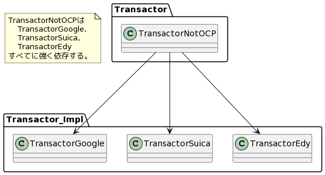

下記は、TransactorIFを導入することによって、上例をOCPに沿うように改善したクラス図と実装である。 TransactorOCPは、TransactorIFの効果によりTransaction Methodの追加に対して全く影響を受けなくなった (実際には、TransactorIFから派生する具象クラスの生成用Factory関数(「Factory」参照) が必要になるため全く影響がないわけではないが、 そのような箇所はソースコード全体でただ一つにすることができるため、 Transaction Methodの追加に対して強固な構造になったと言える)。

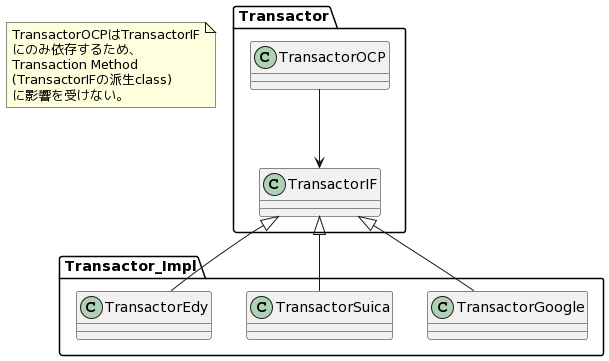

下記にこのクラス図に従ったコードを示す。

```cpp
    // @@@ example/solid/ocp_ut.cpp 122

    class TransactorIF {
    public:
        ...
        bool Charge(Yen price) noexcept { return charge(price); }
        bool Pay(Yen price) noexcept { return pay(price); }

    private:
        virtual bool charge(Yen price) = 0;
        virtual bool pay(Yen price)    = 0;
    };

    class TransactorGoogle : public TransactorIF {
        ...
    };

    class TransactorSuica : public TransactorIF {
        ...
    };

    class TransactorEdy : public TransactorIF {
        ...
    };

    class TransactorOCP {
    public:
        explicit TransactorOCP(std::unique_ptr<TransactorIF>&& transactor) noexcept
            : transactor_{std::move(transactor)}
        {
        }

        bool Charge(Yen price) noexcept { return transactor_->Charge(price); }

        bool Pay(Yen price) noexcept { return transactor_->Pay(price); }

    private:
        std::unique_ptr<TransactorIF> transactor_;
    };
```

ここでは、この原則に沿う実装方法としてポリモーフィズムを使うパターンを紹介したが、 Pimplのようにラッピングを使用するパターンも有用である。

## リスコフの置換原則(LSP)

リスコフの置換原則(LSP, Liskov Substitution Principle)とは、

- 基底クラスを使っているX(関数もしくはクラス)に、 基底クラスの代わりにその派生クラスを渡した場合でも、 Xはその実際の型を知ること無しに正常動作できなければならない

というクラスデザイン上の制約であり、 この制約を守るために下記のような契約プログラミングを行うことが求められる。

- 事前条件を派生クラスで強めることはできない。 つまり、基底クラスよりも強い事前条件を持つ派生クラスを作ってはならない。
- 事後条件を派生クラスで弱めることはできない。 つまり、基底クラスよりも弱い事後条件を持つ派生クラスを作ってはならない。

この原則に従わない実装例を示すために、以下のようなクラスRectangleとその派生クラスSquareを定義する。

```cpp
    // @@@ example/solid/lsp.h 5

    /// @class Rectangle
    /// @brief (0, 0) からの矩形を表す
    class Rectangle {
    public:
        explicit Rectangle(int x, int y) noexcept : x_{x}, y_{y} {}
        ...
        void SetX(int x) noexcept
        {
            auto temp = y_;
            set_x(x);
            assert(temp == y_);  // 「set_xはy_に影響を与えない」が事後条件
        }
        ...

    protected:
        virtual void set_x(int x) noexcept { x_ = x; }

        ...

    private:
        int x_;
        int y_;
    };

    /// @class Rectangle
    /// @brief (0, 0) からの正方形を表す
    class Square : public Rectangle {
    public:
        explicit Square(int x) noexcept : Rectangle{x, x} {}
        ...
    protected:
        virtual void set_x(int x) noexcept override
        {
            Rectangle::set_x(x);
            Rectangle::set_y(x);
        }

        virtual void set_y(int y) noexcept override { set_x(y); }
    };
```

Rectangleのリファレンスを受け取るSetX()とその単体テストを以下のようにすると、 Rectangleのテストでは問題は起こらないが、同じことをSquareに行うとアボートしてしまう (下記例ではASSERT_DEATHを使用しアボートすることを確認している)。

```cpp
    // @@@ example/solid/lsp_ut.cpp 13

    void SetX(Rectangle& rect, int x) noexcept { rect.SetX(x); }

    TEST(LSP_Opt, violation_abort)
    {
        // Rectangleのテスト
        auto rect = Rectangle{0, 0};
        SetX(rect, 3);
        ASSERT_EQ(3, rect.GetX());

        // Squareのテスト
        auto square = Square{0};
        ASSERT_DEATH(SetX(square, 3), "");  // ここでRectangle::SetX()の中のassert()がfailする。
    }
```

上記コードがアボート(assertion fail)してしまったのは

- Rectangle::SetX()は、この実行によるy_の値が不変であることを表明している
- この表明は、Rectangle::set_x()の事後条件となる
- Square::set_x()は、この事後条件を守らず、y_の値を変えてしまった

が原因である。このデザイン上の問題には目をつぶり(Rectangle、Squareを修正せずに)、 しかもアボートしないSetX()の実装を考えてみよう。

SetX()は仮引数で渡されたオブジェクトの実際の型がわからなければアボートを避けることはできない。 従って、 新しいSetX()のコード実装例は以下のようになる。

```cpp
    // @@@ example/solid/lsp_ut.cpp 32

    void SetX(Rectangle& rect, int x) noexcept
    {
        if (dynamic_cast<Square*>(&rect) != nullptr) {
            rect = Square(x);
        }
        else {
            // rectの型は、Rectangle
            rect.SetX(x);
        }
    }

    TEST(LSP, violation_not_abort)
    {
        // Rectangleのテスト
        auto rect = Rectangle{0, 0};
        SetX(rect, 3);
        ASSERT_EQ(3, rect.GetX());

        // Squareのテスト
        auto square = Square{0};
        SetX(square, 3);  // assert()はfailしない。
        ASSERT_EQ(3, square.GetX());
    }
```

上記の新たなSetX()は、アボートはしないがきわめて醜悪且つ、 Rectangleの全派生クラスに依存した、変更に弱い関数となる。

なお、リスコフの置換原則とは関係しないが、上記のdynamic_castを含むSetX()は、 下記のように修正することができる。

```cpp
    // @@@ example/solid/lsp_ut.cpp 61

    void SetX(Rectangle& rect, int x) noexcept
    {
        auto y = rect.GetY();
        rect   = Rectangle(x, y);
    }
```

このSetX()は、Rectangleからの派生クラスに依存していないため、良い解法に見える。 ところが実際にはオブジェクトのスライシングという別の問題を引き起こす。

例示した問題は結局のところデザインの誤りが原因であり、それを修正しない限り、 問題の回避は容易ではない。

一般に、継承関係は、IS-Aの関係と呼ばれる。数学の世界では「正方形 is a 長方形」であるため、 この関係を継承で表したのだが、 「Rectangle::SetX()の性質より導き出されたRectangle::set_x()の事後条件」 により、「クラスSquare is **NOT** a クラスRectangle」となり、 SquareとRectangleは継承関係ではないため問題が発生した。

継承を用いなければこのような問題は発生しないため、public継承を使用する際には、 「本当にその関係は継承で表すべきか(それが最もシンプルな方法か)？」 について熟慮する必要がある。

なお、エクセプション記述子は、関数のエクセプション仕様を強制的にLSPに従わせる仕組みであるが、 C++11から非推奨になり、C++17では規格から削除された。 その理由は、 「[非推奨だった古い例外仕様を削除](https://cpprefjp.github.io/lang/cpp17/remove_deprecated_exception_specifications.html)」 の説明の通り、これを使用し場合、OCPに違反する可能性が高いからである。 従って、原則に従うのみでなく、その他の原則とのバランスも考慮する必要がある。

## インターフェース分離の原則(ISP)

インターフェース分離の原則 (ISP, Interface Segregation Principle)とは、

- クラスは、そのクライアントが使用しないメソッドへの依存を、そのクライアントに強制するべきではない。
  - クラスのインターフェースを巨大にしない。
  - 一つのヘッダファイルに互いが密接な関係を持たない複数のクラスを定義、宣言すべきでない。
  - 一つのヘッダファイルにそのファイルのコンパイルに不要なヘッダファイルをインクルードすべきでない。

というクラスデザイン上の制約である。

まずは、ISPに従っていない例を示す。 下記のStreamReadWriterは、ClientRからはStreamReadWriter::Read()のみが、 ClientWからはStreamReadWriter::Write()のみが使用されている。

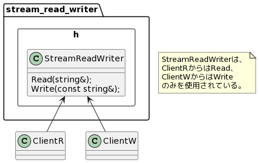

ほとんどのStreamReadWriter使用ファイルでこのような依存関係がある場合、 このクラスは下記のようにStreamReaderとStreamWriterに分割した方が良い(依存関係が小さくなる)。

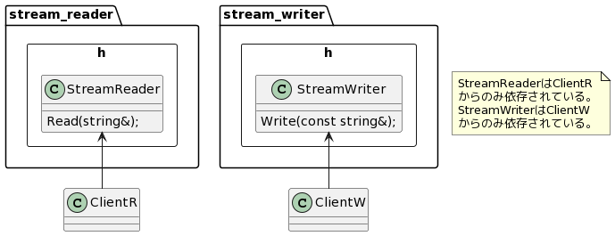

クラスの設計時に統合か分割かで悩むことは多いが、一度統合してしまえば分割は困難であり、 逆に分割されたものを統合することは容易である。このことを考慮すれば、 このような逡巡に解を与えることは簡単である。言うまでもないが、「まずは分割」が原則である。

## 依存関係逆転の原則(DIP)

依存関係逆転の原則 (DIP, Dependency Inversion Principle)とは、

- 上位レベルのモジュールは下位レベルのモジュールに依存すべきではない。
- 抽象は具象に依存すべきではない。

というクラス デザイン上の制約である。

下記ServerNG::Serverは、ClientNG::Clientに非同期サービスを提供する (従って、ServerNG::ServerはClientNG::Clientに対して上位概念である)。

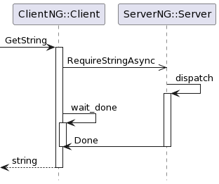

非同期サービスであるServerNG::Server::RequireStringAsync()の完了は ServerNG::ServerがClientNG::Client::Done()を呼び出すことにより通知される。  
その実装、使用例を下記に示す。

```cpp
    // @@@ example/solid/dip_server_ng.h 10

    namespace ServerNG {
    class Server {
    public:
        Server();
        void RequireStringAsync(ClientNG ::Client& client) noexcept;
        ...
    };
    }  // namespace ServerNG
```

```cpp
    // @@@ example/solid/dip_server_ng.cpp 6

    namespace ServerNG {
    namespace {
    void dispatch(ClientNG::Client& client)  // コマンドのディスパッチ
    {
        switch (client.GetNum()) {
        case 1:
            client.Done(new std::string{"hello"});
            break;
        case 2:
            client.Done(new std::string{"good bye"});
            break;
            ...
        }
    }

    void thread_entry(Pipe& pipe)  // サーバーのスレッド関数
    {
        for (;;) {
            ClientNG::Client* client{nullptr};
            auto const        ret = pipe.Read(&client, sizeof(client));
            assert(ret == sizeof(client));

            if (client == nullptr) {  // nullptr受信でサーバー終了
                break;
            }

            dispatch(*client);
        }
    }
    }  // namespace
    ...

    void Server::RequireStringAsync(ClientNG::Client& client) noexcept
    {
        void const* const buff{&client};

        auto ret = pipe_.Write(&buff, sizeof(buff));
        assert(ret == sizeof(&client));
    }
    ...
    }  // namespace ServerNG
```

```cpp
    // @@@ example/solid/dip_client_ng.h 10

    namespace ClientNG {
    class Client {
    public:
        explicit Client(ServerNG::Server& server) noexcept : server_{server}, pipe_{}, num_{0} {}

        std::string GetString(uint32_t num);

        void Done(std::string* str) noexcept  // サーバーからクライアントへのコマンド終了通知
        {
            auto const ret = pipe_.Write(&str, sizeof(str));
            assert(ret == sizeof(str));
        }

        ...
    };
    }  // namespace ClientNG
```

```cpp
    // @@@ example/solid/dip_client_ng.cpp 3

    namespace ClientNG {
    std::string Client::GetString(uint32_t num)
    {
        set_num(num);
        server_.RequireStringAsync(*this);

        return *wait_done();  // 非同期通知待ち
    }

    std::unique_ptr<std::string> Client::wait_done()
    {
        std::string* str{nullptr};
        auto const   ret = pipe_.Read(&str, sizeof(str));
        assert(ret == sizeof(str));

        return std::unique_ptr<std::string>{str};
    }
    }  // namespace ClientNG
```

```cpp
    // @@@ example/solid/dip_ut.cpp 11

    TEST(DIP, ng_pattern)
    {
        auto server = ServerNG::Server{};
        auto client = ClientNG::Client{server};

        auto actual = client.GetString(1);
        ASSERT_EQ("hello", actual);

        actual = client.GetString(2);
        ASSERT_EQ("good bye", actual);

        actual = client.GetString(3);
        ASSERT_EQ("unknown", actual);
    }
```

上記ソースコードから明らかなようにServerNG::ServerとClientNG::Clientは相互に依存している。 このうちの一つはサーバがクライアントに依存(上位概念が下位概念に依存)する問題のある構造となっている。

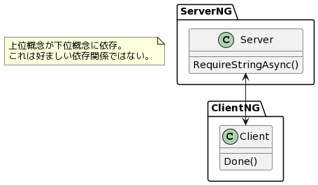

このため、クライアントのバリエーションが増えた場合、容易にServerNG::Serverのコードは肥大化する。 また、ServerNG::Serverを介して各クライアント間にも(暗黙、明示両方の)依存関係が生まれやすいため、 ServerNG::Serverのコード修正は非常に困難になることが予想される。

次にDIPに従い上記コードを改善した例を示す。

```cpp
    // @@@ example/solid/dip_server_ok.h 7

    namespace ServerOK {
    class ClientIF {
    public:
        ClientIF() noexcept : num_{0} {}
        void Done(std::string* str) { done(str); }  // サーバーからクライアントへのコマンド終了通知
        ...
    private:
        virtual void done(std::string* str) = 0;
        ...
    };

    class Server {
    public:
        Server();
        void RequireStringAsync(ClientIF& client) noexcept;
        ...
    };
    }  // namespace ServerOK
```

```cpp
    // @@@ example/solid/dip_server_ok.cpp 5

    namespace ServerOK {
    namespace {
    void dispatch(ClientIF& client)  // コマンドのディスパッチ
    {
        switch (client.GetNum()) {
        case 1:
            client.Done(new std::string{"hello"});
            break;
        case 2:
            client.Done(new std::string{"good bye"});
            break;
            ...
        }
    }

    void thread_entry(Pipe& pipe)  // サーバーのスレッド関数
    {
        for (;;) {
            ClientIF*  client{nullptr};
            auto const ret = pipe.Read(&client, sizeof(client));
            assert(ret == sizeof(client));

            if (client == nullptr) {  // nullptr受信でサーバー終了
                break;
            }

            dispatch(*client);
        }
    }
    }  // namespace
    ...

    void Server::RequireStringAsync(ClientIF& client) noexcept
    {
        void const* const buff{&client};

        auto ret = pipe_.Write(&buff, sizeof(buff));
        assert(ret == sizeof(&client));
    }
    ...
    }  // namespace ServerOK
```

```cpp
    // @@@ example/solid/dip_client_ok.h 10

    namespace ClientOK {
    class Client : public ServerOK::ClientIF {
    public:
        explicit Client(ServerOK::Server& server) noexcept : ClientIF{}, server_{server}, pipe_{} {}

        std::string GetString(uint32_t num);

        ...
    };
    }  // namespace ClientOK
```

```cpp
    // @@@ example/solid/dip_client_ok.cpp 3

    namespace ClientOK {
    std::string Client::GetString(uint32_t num)
    {
        SetNum(num);
        server_.RequireStringAsync(*this);

        return *wait_done();  // 非同期通知待ち
    }

    std::unique_ptr<std::string> Client::wait_done()
    {
        std::string* str{nullptr};
        auto const   ret = pipe_.Read(&str, sizeof(str));
        assert(ret == sizeof(str));

        return std::unique_ptr<std::string>{str};
    }
    }  // namespace ClientOK
```

```cpp
    // @@@ example/solid/dip_ut.cpp 28

    // 使用方法は、ServerNG, ClientNGと同じ。
    TEST(DIP, ok_pattern)
    {
        auto server = ServerOK::Server{};
        auto client = ClientOK::Client{server};

        // 以下、ng_paternと同じ
        ...
    }
```

修正後のコードは、

- ServerOK::ServerはServerOK::ClientIFに依存する。
- ClientOK::ClientはServerOK::ClientIFから派生する。

このクラス図を以下に示す。

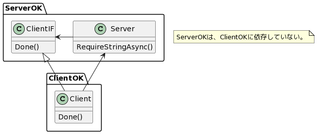

ServerNGとClientNGの双方向依存関係は、ClientOKからServerOKへの単方向依存関係へと改善され、 サーバに影響を与えることなく、クライアントの機能変更やバリエーション追加を行うことが可能となった。

## まとめ

以上で述べたように、SOLIDはオブジェクト指向(OOD/OOP)プログラミングにおいて極めて重要な原則である。 この逸脱はソースコードを劣化させ、ソフトウェアの品質低下や開発費増大に直結するため、 厳守することが求められる。

# デザインパターン

ソースコードを劣化させるアンチパターンには、

- 大きすぎる関数、クラス、ファイル等のソフトウェア構成物
- 複雑怪奇な依存関係
- コードクローン

等があるだろう。 こういった問題は、ひどいソースコードを書かないという強い意志を持ったプログラマの不断の努力と、 そのプログラマを支えるソフトウェア工学に基づいた知識によって回避可能である。 本章ではその知識の一翼をになうデザインパターン、イデオム等を解説、例示する。

なお、ここに挙げるデザインパターン、イデオム等は「適切な場所に適用される場合、 ソースコードをよりシンプルに記述できる」というメリットがある一方で、 「不適切な場所に適用される場合、ソースコードの複雑度を不要に上げてしまう」 という負の一面を持つ。

また、デザインパターン、イデオム等を覚えたてのプログラマは、 自分のスキルが上がったという一種の高揚感や顕示欲を持つため、 それをむやみやたらに多用してしまう状態に陥ることある。このようなプログラマの状態を

- パターン病に罹患した
- パターン猿になった、もしくは単に、猿になった

と呼ぶ。 猿になり不要に複雑なソースコードを書かないために、デザインパターン、イデオム等を使用する場合、 本当にそれが必要か吟味し、不要な場所への適用を避けなければならない。

## ガード節

ガード節とは、 「可能な場合、処理を早期に打ち切るために関数やループの先頭に配置される短い条件文(通常はif文)」 であり、以下のような利点がある。

- 処理の打ち切り条件が明確になる。
- 関数やループのネストが少なくなる。

まずは、ガード節を使っていない例を上げる。

```cpp
    // @@@ example/design_pattern/guard_ut.cpp 24

    /// @fn int32_t SequentialA(char const (&a)[3])
    /// @brief a(配列へのリファレンス)の要素について、先頭から'a'が続く数を返す
    /// @param 配列へのリファレンス
    int32_t SequentialA(char const (&a)[3]) noexcept
    {
        if (a[0] == 'a') {
            if (a[1] == 'a') {
                if (a[2] == 'a') {
                    return 3;
                }
                else {
                    return 2;
                }
            }
            else {
                return 1;
            }
        }
        else {
            return 0;
        }
    }
```

上記の例を読んで一目で何が行われているか、理解できる人は稀である。 一方で、上記と同じロジックである下記関数を一目で理解できない人も稀である。

```cpp
    // @@@ example/design_pattern/guard_ut.cpp 78

    int32_t SequentialA(char const (&a)[3]) noexcept
    {
        if (a[0] != 'a') {  // ガード節
            return 0;
        }
        if (a[1] != 'a') {  // ガード節
            return 1;
        }
        if (a[2] != 'a') {  // ガード節
            return 2;
        }

        return 3;
    }
```

ここまで効果的な例はあまりない。

もう一例、(ガード節導入の効果が前例ほど明確でない)ガード節を使っていないコードを示す。

```cpp
    // @@@ example/design_pattern/guard_ut.cpp 49

    std::optional<std::vector<uint32_t>> PrimeNumbers(uint32_t max_num)
    {
        auto result = std::vector<uint32_t>{};

        if (max_num < 65536) {  // 演算コストが高いためエラーにする
            if (max_num >= 2) {
                auto is_num_prime = std::vector<bool>(max_num + 1, true);  // falseなら素数でない
                is_num_prime[0] = is_num_prime[1] = false;
                auto prime_num                    = 2U;  // 最初の素数

                do {
                    result.emplace_back(prime_num);
                    prime_num = next_prime_num(prime_num, is_num_prime);
                } while (prime_num < is_num_prime.size());
            }

            return result;
        }

        return std::nullopt;
    }
```

上記にガード節を適用した例を下記する。

```cpp
    // @@@ example/design_pattern/guard_ut.cpp 95

    std::optional<std::vector<uint32_t>> PrimeNumbers(uint32_t max_num)
    {
        if (max_num >= 65536) {  // ガード節。演算コストが高いためエラーにする。
            return std::nullopt;
        }

        auto result = std::vector<uint32_t>{};

        if (max_num < 2) {  // ガード節。2未満の素数はない。
            return result;
        }

        auto is_num_prime = std::vector<bool>(max_num + 1, true);  // falseなら素数でない。
        is_num_prime[0] = is_num_prime[1] = false;
        auto prime_num                    = 2U;  // 最初の素数

        do {
            result.emplace_back(prime_num);
            prime_num = next_prime_num(prime_num, is_num_prime);
        } while (prime_num < is_num_prime.size());

        return result;
    }
```

ガード節を使っていない例に比べて、

- ネストが減って読みやすくなった
- max_numが1, 2, 65535, 65536である場合がロジックの境界値であることが一目でわかるようになった

といった改善はされたものの、最初の例ほどのレベル差はない。 しかし、ソースコードの改善やリファクタリングのほとんどは、このようなものであり、 この少しのレベルアップが数か月後、数年後に大きな差を生み出すことを忘れてはならない。

## BitmaskType

下記のようなビットマスク表現は誤用しやすいインターフェースである。 修正や拡張等に関しても脆弱であるため、避けるべきである。

```cpp
    // @@@ example/design_pattern/enum_operator.h 6

    class Animal {
    public:
        struct PhisicalAbility {  // オブジェクトの状態を表すためのビットマスク
            static constexpr auto Run  = 0b0001U;
            static constexpr auto Fly  = 0b0010U;
            static constexpr auto Swim = 0b0100U;
        };

        // paにはPhisicalAbilityのみを受け入れたいが、実際にはすべてのuint32_tを受け入れる。
        explicit Animal(uint32_t pa) noexcept : phisical_ability_{pa} {}

        uint32_t GetPhisicalAbility() const noexcept { return phisical_ability_; }
        ...
    };
```

```cpp
    // @@@ example/design_pattern/enum_operator_ut.cpp 13

    Animal dolphin{Animal::PhisicalAbility::Swim};  // OK
    ASSERT_EQ(Animal::PhisicalAbility::Swim, dolphin.GetPhisicalAbility());

    Animal uma{0xff};  // NG 誤用だが、コンストラクタの仮引数の型がuint32_tなのでコンパイル可能
```

上記のような誤用を防ぐために、 enumによるビットマスク表現を使用して型チェックを強化した例を以下に示す。 このテクニックは、STLのインターフェースとしても使用されている強力なイデオムである。

```cpp
    // @@@ example/design_pattern/enum_operator.h 30

    class Animal {
    public:
        enum class PhisicalAbility : uint32_t {
            Run  = 0b0001,
            Fly  = 0b0010,
            Swim = 0b0100,
        };

        explicit Animal(PhisicalAbility pa) noexcept : phisical_ability_{pa} {}

        PhisicalAbility GetPhisicalAbility() const noexcept { return phisical_ability_; }

    private:
        PhisicalAbility const phisical_ability_;
    };

    // &, | &=, |=, IsTrue, IsFalseの定義
    constexpr Animal::PhisicalAbility operator&(Animal::PhisicalAbility x,
                                                Animal::PhisicalAbility y) noexcept
    {
        return static_cast<Animal::PhisicalAbility>(static_cast<uint32_t>(x)
                                                    & static_cast<uint32_t>(y));
    }

    constexpr Animal::PhisicalAbility operator|(Animal::PhisicalAbility x,
                                                Animal::PhisicalAbility y) noexcept
    {
        return static_cast<Animal::PhisicalAbility>(static_cast<uint32_t>(x)
                                                    | static_cast<uint32_t>(y));
    }

    inline Animal::PhisicalAbility& operator&=(Animal::PhisicalAbility& x,
                                               Animal::PhisicalAbility  y) noexcept
    {
        return x = x & y;
    }

    ...
```

```cpp
    // @@@ example/design_pattern/enum_operator_ut.cpp 28

    // コンストラクタの仮引数の型が厳密になったためコンパイル不可
    // これにより誤用を防ぐ
    // Animal uma{0xff};

    // C++17から下記はコンパイル可能となったが、アクシデントでこのようなミスはしないだろう
    auto uma = Animal{Animal::PhisicalAbility{0xff}};

    auto dolphin = Animal{Animal::PhisicalAbility::Swim};
    ASSERT_EQ(Animal::PhisicalAbility::Swim, dolphin.GetPhisicalAbility());

    auto pa = Animal::PhisicalAbility{Animal::PhisicalAbility::Run};
    pa |= Animal::PhisicalAbility::Swim;

    auto human = Animal{pa};
    ASSERT_TRUE(IsTrue(Animal::PhisicalAbility::Run & human.GetPhisicalAbility()));
```

この改善により、Animalのコンストラクタに域値外の値を渡すことは困難になった (少なくとも不注意で間違うことはないだろう)。 この修正の延長で、Animal::GetPhisicalAbility()の戻り値もenumになり、これも誤用が難しくなった。

## Pimpl

このパターンは、「クラスA(a.cpp、a.hで宣言、定義)を使用するクラスにAの実装の詳細を伝搬させたくない」 ような場合に使用する。 そのためオープン・クローズドの原則(OCP)の実装方法としても有用である。

一般的に、STLライブラリのパースは多くのCPUタイムを消費する。 クラスAがSTLクラスをメンバに使用し、a.hにそのSTLヘッダファイルがインクルードされた場合、 a.hをインクルードするファイルをコンパイルする度にそのSTLヘッダファイルはパースされる。 これはさらに多くのCPUタイムの消費につながり、ソースコード全体のビルドは遅くなる。 こういった問題をあらかじめ避けるためにも有効な手段ではあるが、 そのトレードオフとして実行速度は若干遅くなる。

下記は、Pimplイデオム未使用の、std::stringに依存したクラスStringHolderOldの例である。

```cpp
    // @@@ example/design_pattern/string_holder_old.h 3
    // このファイルには<string>が必要

    #include <memory>
    #include <string>

    class StringHolderOld final {
    public:
        StringHolderOld();

        void        Add(char const* str);
        char const* GetStr() const;

    private:
        std::unique_ptr<std::string> str_;
    };
```

```cpp
    // @@@ example/design_pattern/string_holder_old.cpp 1

    #include "string_holder_old.h"

    StringHolderOld::StringHolderOld() : str_{std::make_unique<std::string>()} {}

    void StringHolderOld::Add(char const* str) { *str_ += str; }

    char const* StringHolderOld::GetStr() const { return str_->c_str(); }
```

下記は、上記クラスStringHolderOldにPimplイデオムを適用したクラスStringHolderNewの例である。

```cpp
    // @@@ example/design_pattern/string_holder_new.h 3
    // このファイルには<string>は不要

    #include <memory>

    class StringHolderNew final {
    public:
        StringHolderNew();

        void        Add(char const* str);
        char const* GetStr() const;
        ~StringHolderNew();  // デストラクタは.cppで=defaultで定義

    private:
        class StringHolderNewCore;  // StringHolderNewの振る舞いは、StringHolderNewCoreに移譲
        std::unique_ptr<StringHolderNewCore> core_;
    };
```

```cpp
    // @@@ example/design_pattern/string_holder_new.cpp 1
    // このファイルには<string>が必要

    #include <string>

    #include "string_holder_new.h"

    class StringHolderNew::StringHolderNewCore final {
    public:
        StringHolderNewCore() = default;
        void Add(char const* str) { str_ += str; }

        char const* GetStr() const noexcept { return str_.c_str(); }

    private:
        std::string str_{};
    };

    StringHolderNew::StringHolderNew() : core_{std::make_unique<StringHolderNewCore>()} {}

    void StringHolderNew::Add(char const* str) { core_->Add(str); }

    char const* StringHolderNew::GetStr() const { return core_->GetStr(); }

    // この宣言、定義をしないと、StringHolderNewをインスタンス化した場所では、
    // StringHolderNewCoreが不完全型であるため、std::unique_ptrが実体化できず、コンパイルエラーとなる。
    // この場所であれば、StringHolderNewCoreは完全型であるためstd::unique_ptrが実体化できる。
    StringHolderNew::~StringHolderNew() = default;
```

下記図は、上記ファイルやそれらを使用するファイルの依存関係である。 string_holder_old.hは、std::stringに依存しているが、string_holder_new.hは、 std::stringに依存していないこと、 それによってStringHolderNewを使用するファイルから、std::stringへの依存を排除できていることがわかる。

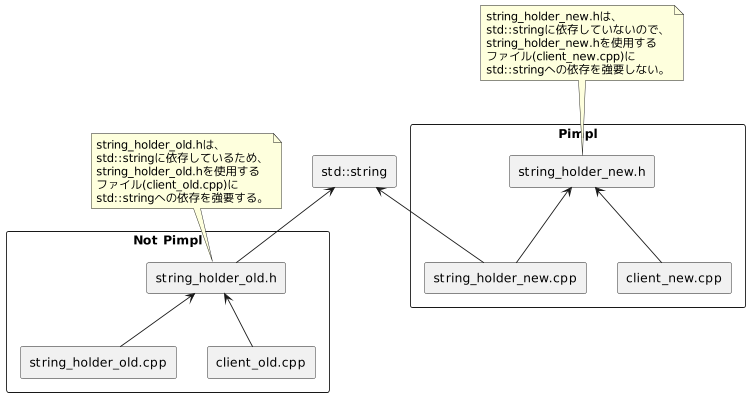

このパターンを使用して問題のある依存関係をリファクタリングする例を示す。

まずは、リファクタリング前のコードを下記する。

```cpp
    // in lib/h/widget.h

    #include "gtest/gtest.h"

    class Widget {
    public:
        void     DoSomething();
        uint32_t GetValue() const;
        // 何らかの宣言

    private:
        uint32_t gen_xxx_data(uint32_t a);
        uint32_t xxx_data_{1};
        FRIEND_TEST(Pimpl, widget_ng);  // 単体テストをfriendにする
    };
```

```cpp
    // in lib/src/widget.cpp

    #include "widget.h"

    void Widget::DoSomething()
    {
        // 何らかの処理
        xxx_data_ = gen_xxx_data(xxx_data_);
    }

    uint32_t Widget::GetValue() const { return xxx_data_; }

    uint32_t WidgetNG::Widget::gen_xxx_data(uint32_t a) { return a * 3; }
```

```cpp
    // in lib/ut/widget_ut.cpp

    #include "widget.h"

    TEST(Pimpl, widget_ng)
    {
        Widget w;

        ASSERT_EQ(1, w.xxx_data_);  // privateのテスト
        w.DoSomething();
        ASSERT_EQ(3, w.xxx_data_);        // privateのテスト
        ASSERT_EQ(9, w.gen_xxx_data(3));  // privateのテスト

        ASSERT_EQ(3, w.GetValue());
    }
```

何らかの事情により、単体テストでprivateなメンバにアクセスする必要があったため、 単体テストクラスをテスト対象クラスのfriendすることで、それを実現している。

単体テストクラスをテスト対象クラスのfriendにするためには、 上記コードの抜粋である下記を記述する必要がある。

```cpp
        FRIEND_TEST(Pimpl, widget_ng);  // 単体テストをfriendにする
```

このマクロは、gtest.h内で定義されているため、widget.hからgtest.hをインクルードしている。

このため、ファイルの依存関係は下記のようになる。

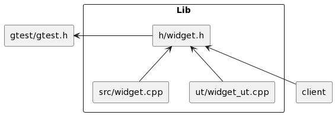

この依存関係は、Widgetのクライアントに不要な依存関係を強要してしまう問題のある構造を作り出す。

この問題をPimplによるリファクタリングで解決したコードを以下に示す (コンパイラのインクルードパスにはlib/hのみが入っていることを前提とする)。

```cpp
    // in lib/h/widget.h

    #include <memory>

    class Widget {
    public:
        Widget();   // widget_pimplは不完全型であるため、コンストラクタ、
        ~Widget();  // デストラクタはインラインにできない
        void     DoSomething();
        uint32_t GetValue() const;
        // 何らかの宣言

        struct widget_pimpl;  // 単体テストのため、publicとするが、実装はsrc/の下に置くため、
                              // 単体テスト以外の外部からのアクセスはできない

    private:
        std::unique_ptr<widget_pimpl> widget_pimpl_;
    };
```

```cpp
    // in lib/src/widget.cpp

    #include "widget_internal.h"

    // widget_pimpl
    void Widget::widget_pimpl::DoSomething()
    {
        // 何らかの処理
        xxx_data_ = gen_xxx_data(xxx_data_);
    }

    uint32_t Widget::widget_pimpl::gen_xxx_data(uint32_t a) { return a * 3; }

    // Widget
    void     Widget::DoSomething() { widget_pimpl_->DoSomething(); }
    uint32_t Widget::GetValue() const { return widget_pimpl_->xxx_data_; }

    // ヘッダファイルの中では、widget_pimplは不完全型であるため、コンストラクタ、
    // デストラクタは下記に定義する
    Widget::Widget() : widget_pimpl_{std::make_unique<Widget::widget_pimpl>()} {}
    Widget::~Widget() = default;
```

```cpp
    // in lib/src/widget_internal.h

    #include "widget.h"

    struct Widget::widget_pimpl {
        void     DoSomething();
        uint32_t gen_xxx_data(uint32_t a);
        uint32_t xxx_data_{1};
    };
```

```cpp
    // in lib/ut/widget_ut.cpp

    #include "../src/widget_internal.h"  // 単体テストのみに、このようなインクルードを認める
    #include "gtest/gtest.h"

    TEST(Pimpl, widget_ok)
    {
        Widget::widget_pimpl wi;

        ASSERT_EQ(1, wi.xxx_data_);
        wi.DoSomething();
        ASSERT_EQ(3, wi.xxx_data_);
        ASSERT_EQ(9, wi.gen_xxx_data(3));

        Widget w;

        w.DoSomething();
        ASSERT_EQ(3, w.GetValue());
    }
```

このリファクタリングにより、ファイルの依存は下記のようになり、 問題のある構造は解消された。

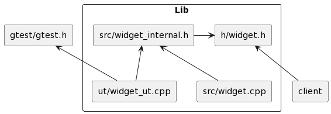

## Accessor

publicメンバ変数とそれにアクセスするソースコードは典型的なアンチパターンであるため、 このようなコードを禁じるのが一般的なプラクティスである。

```cpp
    // @@@ example/design_pattern/accessor_ut.cpp 8

    class A {  // アンチパターン
    public:
        int32_t a_{0};
    };

    void f(A& a) noexcept
    {
        a.a_ = 3;

        // Do something
        ...
    }
```

とはいえ、ソフトウェアのプラクティスには必ずといってほど例外があり、 製品開発の現場において、オブジェクトのメンバ変数にアクセスせざるを得ないような場面は、 稀にではあるが発生する。 このような場合に適用するがのこのイデオムである。

```cpp
    // @@@ example/design_pattern/accessor_ut.cpp 28

    class A {  // Accessorの実装例
    public:
        void SetA(int32_t a) noexcept  // setter
        {
            a_ = a;
        }

        int32_t GetA() const noexcept  // getter
        {
            return a_;
        }

    private:
        int32_t a_{0};
        ...
    };

    void f(A& a) noexcept
    {
        a.SetA(3);

        // Do something
        ...
    }
```

メンバ変数への直接のアクセスに比べ、以下のようなメリットがある。

- アクセスのログを入れることができる。
- メンバ変数へのアクセスをデバッガで捕捉しやすくなる。
- setterに都合の悪い値が渡された場合、何らかの手段を取ることができる(assertや、エラー処理)。
- リファクタリングや機能修正により対象のメンバ変数がなくなった場合においても、 クラスのインターフェースの変更を回避できる(修正箇所を局所化できる)。

一方で、クラスに対するこのような細かい制御は、カプセル化に対して問題を起こしやすい。 下記はその典型的なアンチパターンである。

```cpp
    // @@@ example/design_pattern/accessor_ut.cpp 62

    class A {  // Accessorを使用して細かすぎる制御をしてしまうアンチパターン
    public:
        void SetA(int32_t a) noexcept  // setter
        {
            a_ = a;
        }

        int32_t GetA() const noexcept  // getter
        {
            return a_;
        }

        void Change(bool is_changed) noexcept  // setter
        {
            is_changed_ = is_changed;
        }

        bool IsChanged() const noexcept  // getter
        {
            return is_changed_;
        }

        void DoSomething() noexcept  // is_changed_がtrueの時に、呼び出してほしい
        {
            // Do something
            ...
        }
        ...
    };

    void f(A& a) noexcept
    {
        if (a.GetA() != 3) {
            a.SetA(3);
            a.Change(true);
        }

        ...
    }

    void g(A& a) noexcept
    {
        if (!a.IsChanged()) {
            return;
        }

        a.Change(false);
        a.DoSomething();  // a.IsChanged()がtrueの時に実行する。

        ...
    }
```

上記ソースコードは、オブジェクトaのA::a_が変更された場合、 その後、それをもとに何らかの動作を行うこと(a.DoSomething)を表しているが、 本来オブジェクトaの状態が変わったかどうかはオブジェクトa自体が判断すべきであり、 a.DoSomething()の実行においても、それが必要かどうかはオブジェクトaが判断すべきである。 この考えに基づいた修正ソースコードを下記に示す。

```cpp
    // @@@ example/design_pattern/accessor_ut.cpp 130

    class A {  // 上記アンチパターンからChange()とIsChanged()を削除し、状態の隠蔽レベルを強化
    public:
        void SetA(int32_t a) noexcept  // setter
        {
            if (a_ == a) {
                return;
            }

            a_          = a;
            is_changed_ = true;
        }

        void DoSomething() noexcept
        {
            if (!is_changed_) {
                return;
            }

            // Do something
            ...

            is_changed_ = false;  // 状態変更の取り消し
        }
        ...
    };

    void f(A& a) noexcept
    {
        a.SetA(3);

        ...
    }

    void g(A& a) noexcept
    {
        a.DoSomething();  // DoSomethingは無条件で呼び出す。
                          // 実際に何かをするかどうかは、オブジェクトaが決める。
        ...
    }
```

setterを使用する場合、上記のように処理の隠蔽化には特に気を付ける必要がある。

## Copy-And-Swap

メンバ変数にポインタやスマートポインタを持つクラスに

- copyコンストラクタ
- copy代入演算子
- moveコンストラクタ
- move代入演算子

が必要になった場合、コンパイラが生成するデフォルトの 特殊メンバ関数では機能が不十分であることが多い。

下記に示すコードは、そのような場合の上記4関数の実装例である。

```cpp
    // @@@ example/design_pattern/no_copy_and_swap_ut.cpp 8

    class NoCopyAndSwap final {
    public:
        explicit NoCopyAndSwap(char const* name0, char const* name1)
            : name0_{name0 == nullptr ? "" : name0}, name1_{name1 == nullptr ? "" : name1}
        {
        }

        NoCopyAndSwap(NoCopyAndSwap const& rhs) : name0_{rhs.name0_}, name1_{rhs.name1_} {}

        NoCopyAndSwap(NoCopyAndSwap&& rhs) noexcept
            : name0_{std::exchange(rhs.name0_, nullptr)}, name1_{std::move(rhs.name1_)}
        {
            // move後には、
            //  * name0_はnullptr
            //  * name1_はnullptrを保持したunique_ptr
            // となる。
        }

        NoCopyAndSwap& operator=(NoCopyAndSwap const& rhs)
        {
            if (this == &rhs) {
                return *this;
            }

            // copyコンストラクタのコードクローン
            name0_ = rhs.name0_;
            name1_ = rhs.name1_;  // ここでエクセプションが発生すると*thisが壊れる

            return *this;
        }

        NoCopyAndSwap& operator=(NoCopyAndSwap&& rhs) noexcept
        {
            if (this == &rhs) {
                return *this;
            }

            // moveコンストラクタのコードクローン
            name0_ = std::exchange(rhs.name0_, nullptr);
            name1_ = std::string{};  // これがないと、name1_の値がrhs.name1_にスワップされる
            name1_ = std::move(rhs.name1_);

            return *this;
        }

        char const*        GetName0() const noexcept { return name0_; }
        std::string const& GetName1() const noexcept { return name1_; }
        ~NoCopyAndSwap() = default;

    private:
        char const* name0_;  // 問題やその改善を明示するために、敢えてname0_をchar const*としたが、
                             // 本来ならば、std::stringかstd::string_viewを使うべき
        std::string name1_;
    };
```

コード内のコメントで示したように、このコードには以下のような問題がある。

- copy代入演算子には、エクセプション安全性の保証がない。
- 上記4関数は似ているにも関わらず、微妙な違いがあるためコードクローンとなっている。

ここで紹介するCopy-And-Swapはこのような問題を解決するためのイデオムである。

実装例を以下に示す。

```cpp
    // @@@ example/design_pattern/copy_and_swap_ut.cpp 6

    class CopyAndSwap final {
    public:
        explicit CopyAndSwap(char const* name0, char const* name1)
            : name0_{name0 == nullptr ? "" : name0}, name1_{name1 == nullptr ? "" : name1}
        {
        }

        CopyAndSwap(CopyAndSwap const& rhs) : name0_{rhs.name0_}, name1_{rhs.name1_} {}

        CopyAndSwap(CopyAndSwap&& rhs) noexcept
            : name0_{std::exchange(rhs.name0_, nullptr)}, name1_{std::move(rhs.name1_)}
        {
            // move後には、
            //  * name0_はnullptr
            //  * name1_は""を保持したstd::string
            // となる。
        }

        CopyAndSwap& operator=(CopyAndSwap const& rhs)
        {
            if (this == &rhs) {
                return *this;
            }

            // copyコンストラクタの使用
            CopyAndSwap tmp{rhs};  // ここでエクセプションが発生しても、tmp以外、壊れない

            Swap(tmp);

            return *this;
        }

        CopyAndSwap& operator=(CopyAndSwap&& rhs) noexcept
        {
            if (this == &rhs) {
                return *this;
            }

            CopyAndSwap tmp{std::move(rhs)};  // moveコンストラクタ

            Swap(tmp);

            return *this;
        }

        void Swap(CopyAndSwap& rhs) noexcept
        {
            std::swap(name0_, rhs.name0_);
            std::swap(name1_, rhs.name1_);
        }

        char const*        GetName0() const noexcept { return name0_; }
        std::string const& GetName1() const noexcept { return name1_; }
        ~CopyAndSwap() = default;

    private:
        char const* name0_;  // 問題やその改善を明示するために、敢えてname0_をchar const*としたが、
                             // 本来ならば、std::stringかstd::string_viewを使うべき
        std::string name1_;
    };
```

上記CopyAndSwapのcopyコンストラクタ、moveコンストラクタに変更はない。 また、CopyAndSwap::Swapに関してもstd::vector等が持つswapと同様のものである。 このイデオムの特徴は、copy代入演算子、 move代入演算子が各コンストラクタとSwap関数により実装されている所にある。 これによりエクセプション安全性の保証を持つ4関数をコードクローンすることなく実装できる。